# ARIMA Model for Materials Sector Fund

During exploratory data analysis (EDA), it was observed that the raw data is often non-stationary, exhibiting trends, seasonality, and other complex patterns that can make modeling and forecasting difficult. To address this issue, the data is often differentiated to achieve stationarity, which is a key assumption of the ARIMA model.

Differencing involves calculating the difference between each data point and the previous data point, which can help to remove trends and seasonality from the data. The goal is to create a new series of data that is stationary, meaning that the statistical properties of the data do not change over time.

#### Differentiated Time Series Plot

**Plot**

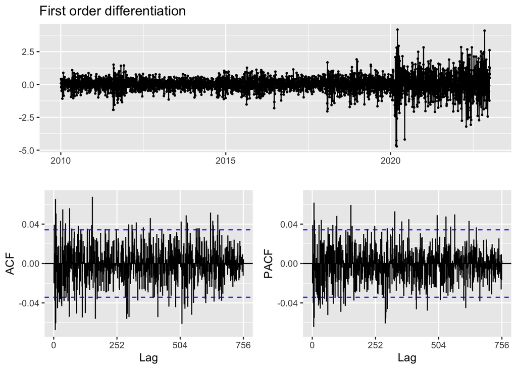

```r
#import the data
df <- read.csv("DATA/CLEANED DATA/XLB_raw_data.csv")
#convert to time series data
myts<-ts(df$XLB.Adjusted,frequency=252,start=c(2010,1,1), end = c(2023,3,1))
#First order differentiation
df1 <- diff(myts)
# Plot
myts  %>% diff() %>% ggtsdisplay(main = "First order differentiation")
```

**ACF**

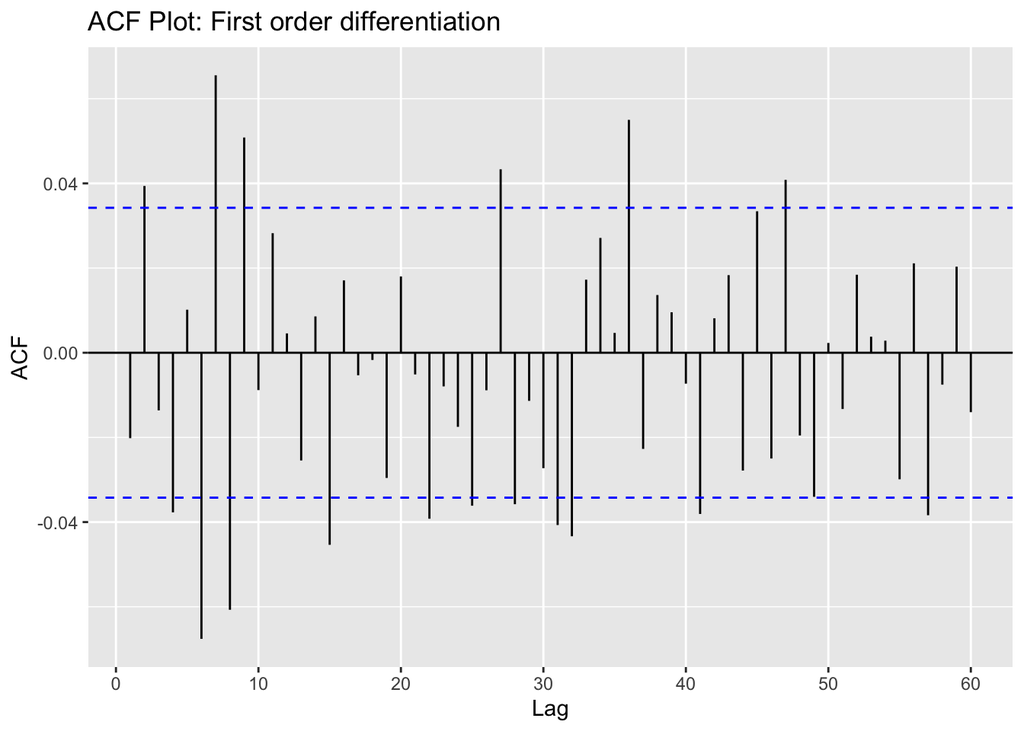

```r
#ACF plot
ggAcf(df1,60,main="ACF Plot: First order differentiation")
```

**PACF**

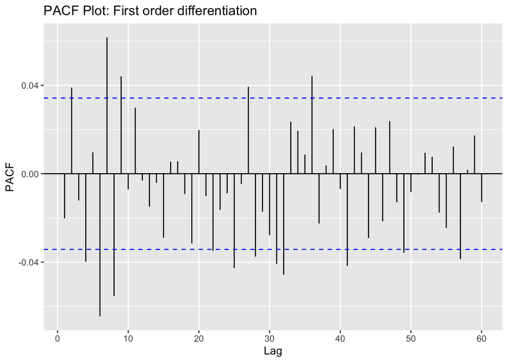

```r
ggPacf(df1,60,main="PACF Plot: First order differentiation")
```

**ADF Test**

```r
tseries::adf.test(df1)
```

```
    Augmented Dickey-Fuller Test

data:  df1
Dickey-Fuller = -15.19, Lag order = 14, p-value = 0.01
alternative hypothesis: stationary
```

After analyzing the ACF and PACF plots, it can be observed that most of the bar lines lie between the blue lines, indicating that the time series is stationary. This has been further confirmed through an Augmented Dickey-Fuller test as the p-value is less than 0.05. Once the data is stationary, the next step is to model it using ARIMA. The combination of ACF and PACF plots can help determine the appropriate values for p, d, and q in the ARIMA model. The order of differencing required to achieve stationarity gives the d value. The p value is determined by examining significant spikes at various lags in the PACF plot, while the q value is determined through significant spikes in the ACF plot. It is important to consider other methods such as grid search and information criteria to ensure the most appropriate model is selected.

Here the parameters are d = 1 p = 0(PACF Plot) q = 0 (ACF Plot)

#### Model Selection

**ARIMA(0,1,0) Result**

```r
Arima(myts,order=c(0,1,0),include.drift=TRUE)
```

```
Series: myts
ARIMA(0,1,0) with drift

Coefficients:
       drift
      0.0171
s.e.  0.0112

sigma^2 = 0.4091:  log likelihood = -3185.81
AIC=6375.63   AICc=6375.63   BIC=6387.82
```

**Auto Arima Model**

```r
auto.arima(myts)
```

```
Series: myts
ARIMA(0,1,0) with drift

Coefficients:
       drift
      0.0171
s.e.  0.0112

sigma^2 = 0.4091:  log likelihood = -3185.81
AIC=6375.63   AICc=6375.63   BIC=6387.82
```

In the Model selection, the chosen model and the suto.arima generated model are the same i.e.(0,1,0). So this is the best model for th series. We can proceed with the further model diagnostic for the chosen best model i.e. (0,1,0), to look into the details of the model.

#### Model Diagnostic

**Model Plot**

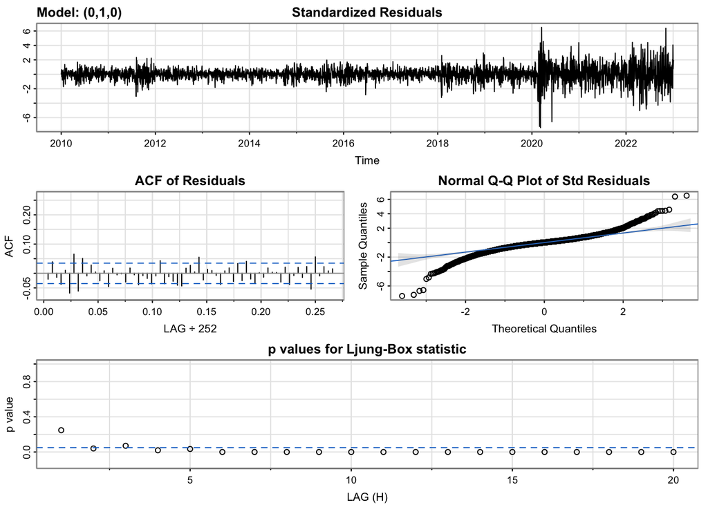

```r
model_output <- capture.output(sarima(myts,0,1,0))
```

**Model**

```r
cat(model_output[9:38], model_output[length(model_output)], sep = "\n")
```

```
$fit

Call:
arima(x = xdata, order = c(p, d, q), seasonal = list(order = c(P, D, Q), period = S),
    xreg = constant, transform.pars = trans, fixed = fixed, optim.control = list(trace = trc,
        REPORT = 1, reltol = tol))

Coefficients:
      constant
        0.0171
s.e.    0.0112

sigma^2 estimated as 0.409:  log likelihood = -3185.81,  aic = 6375.63

$degrees_of_freedom
[1] 3277

$ttable
         Estimate     SE t.value p.value
constant   0.0171 0.0112  1.5343   0.125

$AIC
[1] 1.944975

$AICc
[1] 1.944976

$BIC
[1] 1.948694
```

#### Forcast

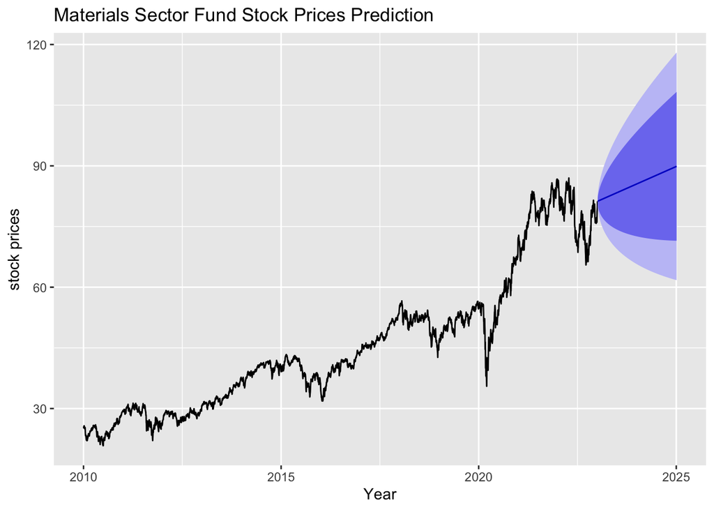

```r
myts %>%
  Arima(order=c(0,1,0),include.drift = TRUE) %>%
  forecast %>%
  autoplot(main = "Materials Sector Fund Stock Prices Prediction") +
  ylab("stock prices") + xlab("Year")
```

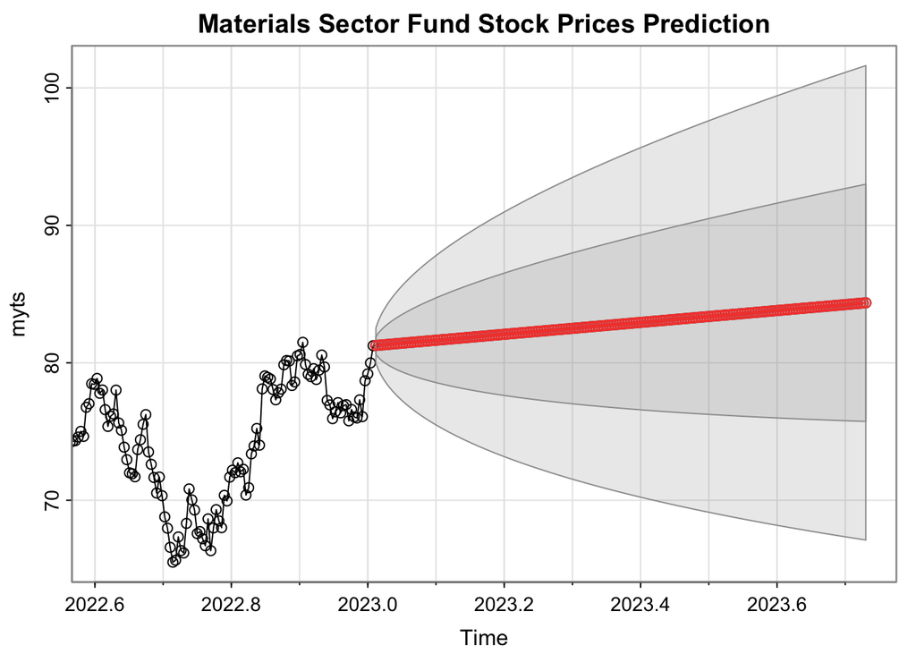

```
$pred
Time Series:
Start = c(2023, 4)
End = c(2023, 185)
Frequency = 252
  [1] 81.26254 81.27968 81.29681 81.31395 81.33109 81.34823 81.36536 81.38250
  [9] 81.39964 81.41678 81.43392 81.45105 81.46819 81.48533 81.50247 81.51960
 [17] 81.53674 81.55388 81.57102 81.58816 81.60529 81.62243 81.63957 81.65671
 [25] 81.67384 81.69098 81.70812 81.72526 81.74240 81.75953 81.77667 81.79381
 [33] 81.81095 81.82808 81.84522 81.86236 81.87950 81.89664 81.91377 81.93091
 [41] 81.94805 81.96519 81.98233 81.99946 82.01660 82.03374 82.05088 82.06801
 [49] 82.08515 82.10229 82.11943 82.13657 82.15370 82.17084 82.18798 82.20512
 [57] 82.22225 82.23939 82.25653 82.27367 82.29081 82.30794 82.32508 82.34222
 [65] 82.35936 82.37649 82.39363 82.41077 82.42791 82.44505 82.46218 82.47932
 [73] 82.49646 82.51360 82.53073 82.54787 82.56501 82.58215 82.59929 82.61642
```

[output cut: 45 more lines]

```r
sarima.for(myts,182, 0,1,0, main='Materials Sector Fund Stock Prices Prediction')
```

The two figures above show an idea of the short term and the long-term forecasted stock price. The forecasted values is be based on the estimated parameters of the model, which were obtained by fitting it to the historical data. One way to assess the accuracy of the forecasts is to use cross-validation, which involves splitting the data into training and testing sets and comparing the predicted values to the actual values in the test set. This can help to identify any potential problems with the model and to fine-tune the model parameters.

**12 Step ahead Cross Validation**

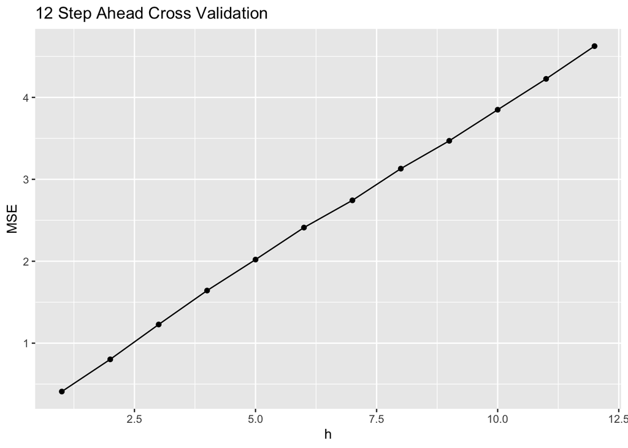

```r
#a seasonal cross validation using 12 steps ahead forecasts
farima1 <- function(x, h){forecast(Arima(x, order=c(0,1,0)), h=h)}

# Compute cross-validated errors for up to 12 steps ahead
e <- tsCV(myts, forecastfunction = farima1, h = 12)

# Compute the MSE values and remove missing values
mse <- colMeans(e^2, na.rm = TRUE)

# Plot the MSE values against the forecast horizon
data.frame(h = 1:12, MSE = mse) %>%
  ggplot(aes(x = h, y = MSE)) + geom_point()+geom_line()+ggtitle("12 Step Ahead Cross Validation")
```

**1 Step ahead Cross Validation**

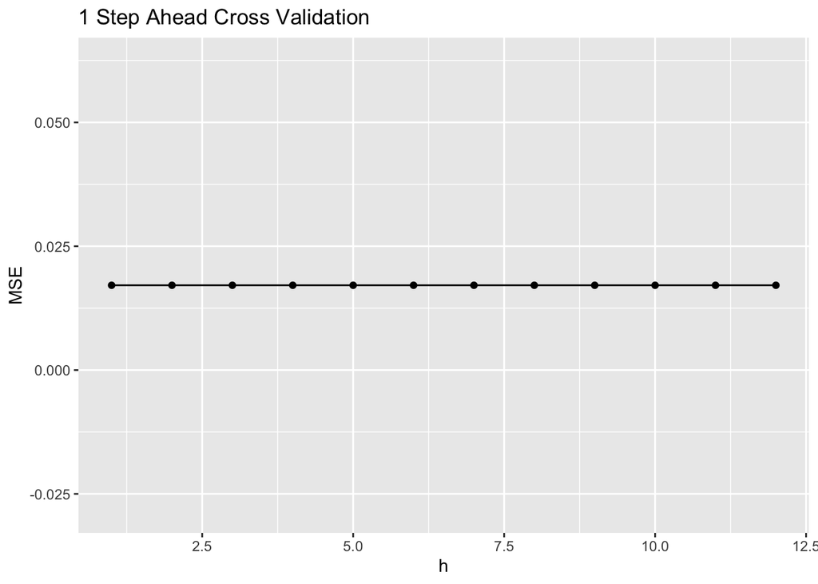

```r
#a seasonal cross validation using 1 steps ahead forecasts
farima1 <- function(x, h){forecast(Arima(x, order=c(0,1,0)),h=h)}

# Compute cross-validated errors for up to 1 steps ahead
e <- tsCV(myts, forecastfunction = farima1, h = 1)
mse <-abs(mean(e,na.rm=TRUE))

# Plot the MSE values against the forecast horizon
data.frame(h = 1:12, MSE = mse) %>%
  ggplot(aes(x = h, y = MSE)) + geom_point()+geom_line()+ggtitle("1 Step Ahead Cross Validation")
```

The one-step-ahead forecasting plot shows that the MSE seems to be stable. The MSE is tend to rise by 12 steps at each step of cross-validation. Lastly, the above-mentioned ARIMA model should be compared to benchmark methods before being used for a long time.

#### Model Comparison

**Plot**

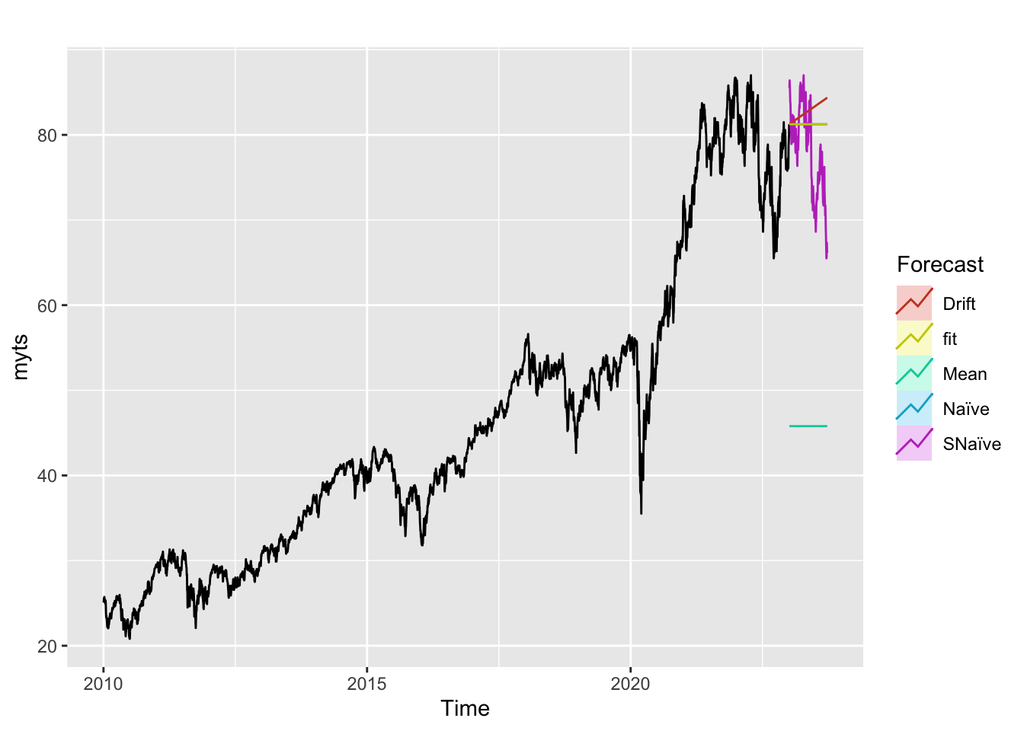

```r
fit <- Arima(myts, order=c(0,1,0))
autoplot(myts) +
  autolayer(meanf(myts, h=182),
            series="Mean", PI=FALSE) +
  autolayer(naive(myts, h=182),
            series="Naïve", PI=FALSE) +
  autolayer(snaive(myts, h=182),
            series="SNaïve", PI=FALSE)+
  autolayer(rwf(myts, h=182, drift=TRUE),
            series="Drift", PI=FALSE)+
  autolayer(forecast(fit,182),
            series="fit",PI=FALSE) +
  guides(colour=guide_legend(title="Forecast"))
```

**Model Error Table**

```r
summary <- summary(fit)
snaive <- snaive(myts, h=182)
accuracy(snaive)
```

```
                   ME    RMSE      MAE      MPE     MAPE MASE      ACF1
Training set 4.379863 8.90169 6.586829 8.128289 13.12814    1 0.9936968
```

```r
summary
```

```
Series: myts
ARIMA(0,1,0)

sigma^2 = 0.4093:  log likelihood = -3186.99
AIC=6375.98   AICc=6375.98   BIC=6382.08

Training set error measures:
                     ME      RMSE       MAE        MPE      MAPE       MASE
Training set 0.01714022 0.6396371 0.4338019 0.02656752 0.9608813 0.06585898
                    ACF1
Training set -0.02017707
```

[output not shown]